# Brexit ? See it from another way !

## 1. Introduction

**Brexit** is just around the corner, with the whole UK discussing, debating and fighting here and there. Meanwhile, In the Internet, especially in Twitter, things are also not peaceful. Everytime we search anything related to brexit, hundreds of new tweets will fill our screen. Since we have already been exposed to the complecated and boring articles for a long time, the essay aims to dig out the hidden implication in shorter but flexible tweets and information from their generators. The essay flows as below:

- Introducing data: Scrapping, Deduplicating and Processing
- Analyzing tweets: Time, Text and Sentiment
- Exploring geography: Map Distribution and Prediction Model

Due to GitHub's uploading limits, the whole project can only be showed here:

https://drive.google.com/drive/folders/1zz5DfLJJMNQNCkcn8peFVloWxbaC-k5_?usp=sharing

```python
import numpy as np
import pandas as pd
import seaborn as sns
import matplotlib.pyplot as plt
import matplotlib.cm
import imageio
import pickle
import json

# cluster
from sklearn.cluster.bicluster import SpectralCoclustering

# Pearson correlation coefficient
from scipy.stats import pearsonr

# plot more beautiful
from mpl_toolkits.axes_grid1.inset_locator import inset_axes, mark_inset
from mpl_toolkits.basemap import Basemap
from matplotlib.patches import Polygon
from matplotlib.collections import PatchCollection
from matplotlib.colors import Normalize

# confusion matrix
from sklearn.metrics import confusion_matrix
from sklearn.metrics.pairwise import cosine_similarity

# utils
from collections import Counter
from wordcloud import WordCloud, ImageColorGenerator # python 3.7 may need more efforts to install it well.
```

```python
datafile = "data/"

# import my data and preprocess
with open(datafile+"tweets_data", "rb") as file:
    tweets_data = pickle.load(file)

with open(datafile+"users_data", "rb") as file:
    users_data = pickle.load(file)

with open(datafile+"tweets_info", "rb") as file:
    id_time = pickle.load(file)

with open(datafile+"tweets_text", "rb") as file:
    hashtags, user_mentions, words  = pickle.load(file)

with open(datafile+"user_location", "rb") as file:
    user_location = pickle.load(file)

word_count = pd.Series(dict(Counter([i for item in words for i in item]).most_common()))
hashtag_count = pd.Series(dict(Counter([i for item in hashtags for i in item]).most_common()))
mention_count = pd.Series(dict(Counter([i for item in user_mentions for i in item]).most_common()))
```

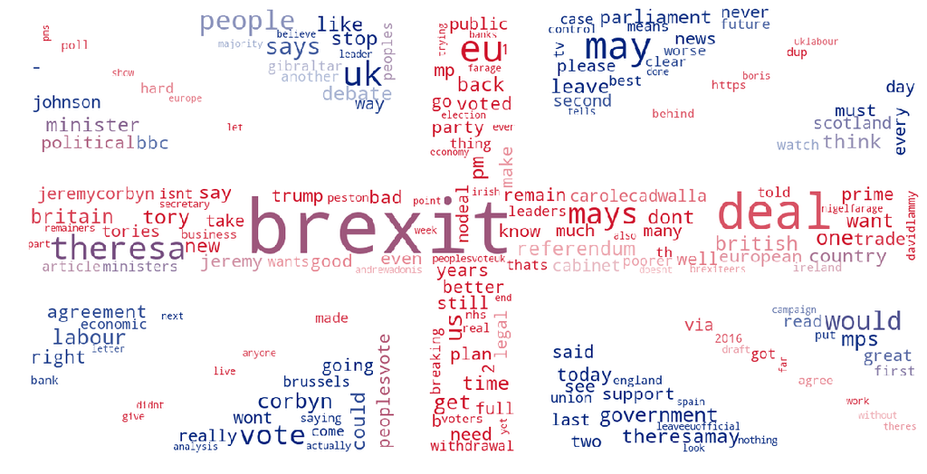

```python
def draw_cloud(word_freq):
    """Generate word cloud
    Args:
        word_freq:
            A dict. A dict of words and their frequencies.

    Python 3.7 may need more efforts to install wordcloud package well.
    """
    fig, ax = plt.subplots(figsize=(20, 40))

    # set background photo
    mask_img = imageio.imread("britainflag.png")
    image_colors = ImageColorGenerator(mask_img)

    # draw cloud
    cloud = WordCloud(collocations=False,
                      max_words=200,
                      background_color='white',
                      mask=mask_img,
                      ).generate_from_frequencies(word_freq)

    # draw color
    plt.imshow(cloud.recolor(color_func=image_colors))
    plt.axis('off')
    plt.show()

draw_cloud(word_count)
```

> Word cloud is made by acquiring Twitter text data about Brexit.

> From the graph we can see the words related and the size of word implies the importance of it. Here *Theresa May*, *Deal* and *Corbyn* are called lots of times concerning Brexit in Twitter.

## 2. Data Exploration

### 2.1 Scrap Data

The essay scrapped data by Twitter API and stored everything in an **Elasticsearch** Database, which is No-SQL Database thatis really good to nested data structure, i.e. lots of attributes and attributes in attributes. For presentation, The essay created a remote ELasticsearch Database in **AWS** server, with only data on show. The whole data is above **15 GB** in Database and incredible larger in json files.

```python
# %run es_savedata.py
```

> The above code cell can be runned after uncommenting. The file can scrap the tweets by **automatically** recognized the minimum ID in database so far to begin with. So if it meets internet problem, it will recover naturally by himself.

> You may open this link in browser to view my data and just change the "size=1" below if you want to see more:  
> https://search-twitter-r3gv3yfldtos63tbjztf2n4zja.us-east-2.es.amazonaws.com/twitter_brexit/_search?size=1.

### 2.2 Deduplicate Data

Due to strict API rule by Twitter, the essay can only acquire a few thousand tweets every 15 minutes, but tweets concerning brexit is more than twenty thousand within one hour for most cases. The essay therefore implemented more than one API crawler and ran them successively. Thus, data might confront with duplications when adding them all.

```python
# %run es_deduplication.py
```

> The above code cell can be runned by uncommenting. The magic command can run it well.

### 2.3 Process Data

For further research and presentation, the essay makes four different files to store the useful information separately, i.e. **tweets_data**, **users_data**, **tweets_info**, **tweets_text**, which are all pickle file remaining their python structures. They will be presented below.

```python
# %run es_process.py
# %run tweets_process.py
```

> The code cell above takes a long time to handle all **4638226** documents if working with the full database. Thus, I changed the codes to work with AWS database with only a little data. Let's just use the well-done files.  
> The es_process.py is to make **tweets_data** and **users_data**. The tweets_process.py is to make **tweets_info** and **tweets_text**. If necessary, please use them by this order since the last two files are from the first two, for time advantage.

```python
# %run location_process.py
```

> Please this **location_process.py** will spend my Google Map API credits, which spends quite a lot if running the whole process. Let's use the well-done file instead.

```python
print("Tweet Data:\n")
print(json.dumps(tweets_data[15], indent=4, sort_keys=True)) # plot it beautiful
print("\n\nUser Data:\n")
print(json.dumps(users_data[0], indent=4, sort_keys=True))
```

```
Tweet Data:

{
    "created_at": "Tue Nov 20 08:47:51 +0000 2018",
    "favorite_count": 0,
    "hashtags": [
        "Ireland",
        "Brexit"
    ],
    "id": 1064802489613062144,
    "retweet_count": 6,
    "text": "RT @WilliamsJon: Brilliant: @colmoregan\u2019s guide to #Ireland for UK\u2019s #Brexit|eers. As told @ClaireByrneLive. \nhttps://t.co/35qPHOEbca",
    "user_mentions": [
        "Jon Williams",
        "Colm O'Regan",
        "RT\u00c9 ClaireByrneLive"
    ],
    "userid": 2347330281
}


User Data:

{
    "id": 121171051,
    "location": "Corby & East Northamptonshire"
}
```

```python
print("words:\n")
print(word_count.head(2))
print("\n\nhashtags:\n")
print(hashtag_count.head(2))
print("\n\nusers_mention:\n")
print(mention_count.head(2))
print("\n\nid_time:\n")
id_time.head()
```

```
words:

brexit    3022974
deal       945366
dtype: int64


hashtags:

Brexit         458877
PeoplesVote     68801
dtype: int64


users_mention:

Theresa May      112259
Jeremy Corbyn     67771
dtype: int64


id_time:
```

|  | created_at | favorite_count | id | retweet_count | sentiment | userid | time | date | hour |
| --- | --- | --- | --- | --- | --- | --- | --- | --- | --- |
| 0 | 2018-11-09 12:39:33 | 0 | 1060874532788027394 | 0 | 0.000000 | 1585398848 | 759 | 9 | 12 |
| 1 | 2018-11-09 12:39:33 | 0 | 1060874533425549312 | 672 | 0.175000 | 119900697 | 759 | 9 | 12 |
| 2 | 2018-11-09 12:39:33 | 0 | 1060874533731741696 | 4 | 0.050000 | 869562441658662913 | 759 | 9 | 12 |
| 3 | 2018-11-09 12:39:34 | 0 | 1060874535942213632 | 0 | 0.134091 | 2767177542 | 759 | 9 | 12 |
| 4 | 2018-11-09 12:39:34 | 0 | 1060874536172838913 | 48 | -0.400000 | 386542585 | 759 | 9 | 12 |

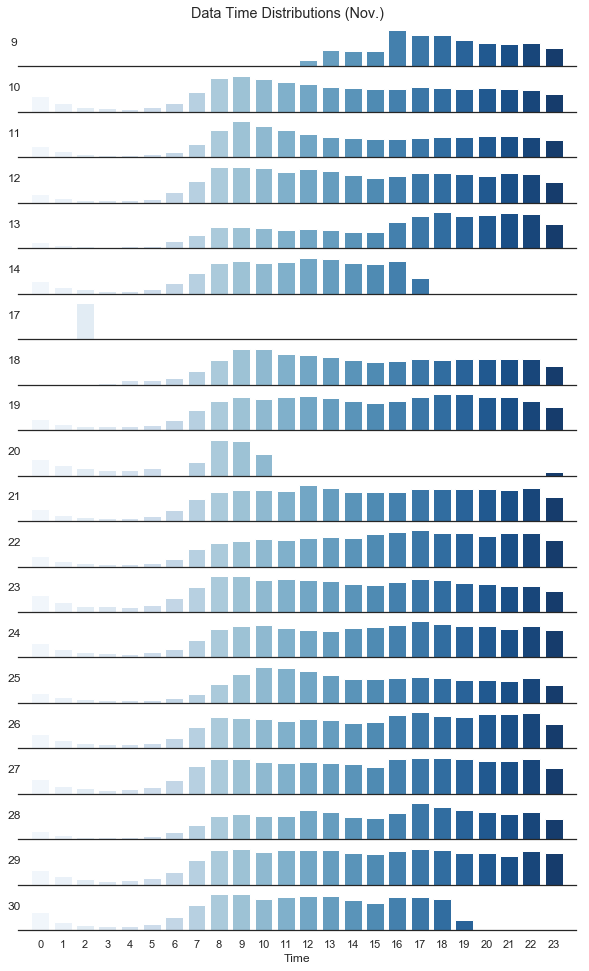

```python
dates = id_time.date.unique()

sns.set(style="white", palette="muted", color_codes=True) # choose color
f, axes = plt.subplots(len(dates), 1, figsize=(10, 15), sharex=True) # share x axis
sns.despine(left=True)

hours = range(24)
full_day = []
for i, date in enumerate(dates):
    # group each day and get its counts, if no then update to 0
    df_dict = id_time[id_time["date"]==date].groupby("hour").size().to_dict()
    for key in hours:
        if key not in df_dict:
            df_dict.update({key:0})
    df = pd.Series(df_dict).reset_index().rename(columns={"index":"hour",0:date})
    # bar plot at one ax
    g = sns.barplot("hour", date, data=df, ax=axes[i], palette="Blues")
    g.set_xlabel("")
    g.set_ylabel(date, rotation=0)
    # update the full day
    if (df[date]!=0).all():
        full_day.append(date)

plt.subplots_adjust(top=0.96)
plt.suptitle("Data Time Distributions (Nov.)",)
plt.setp(axes, yticks=[])
plt.xticks(np.arange(24), tuple(hours))
plt.xlim([-1, 24])
plt.xlabel("Time")
plt.show()
```

> From the graph above, we can see the data was scrapped from November 9 to November 30. Due to strict API limits, some blanks happen at around November 17 and 20. But most other days are fullly acquired.

## 3. Tweets Analysis

The essay acquires the complete day for further study, so as to reduce the bias by hours lacking.

```python
df_complete = id_time[id_time.date.isin(full_day)] # get the full days
```

### 3.1 How Many Tweets?

Firstly, we are going to find how many tweets will come out.

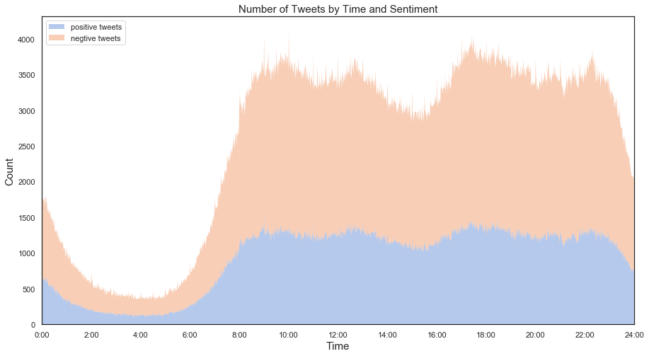

```python
fig, ax = plt.subplots(figsize=(15, 8))

n1, _bins = np.histogram(df_complete.time[df_complete["sentiment"]>0], bins=range(24*60+1)) # positive days
n2, _bins = np.histogram(df_complete.time[df_complete["sentiment"]<=0], bins=range(24*60+1)) # negative days

ax.stackplot(range(24*60), [n1, n2], edgecolor='none', alpha = 0.4) # draw stack hists
ax.set_xticks(60*np.arange(0, 26, 2)) # only draw even hours
ax.set_xticklabels([str(i) + ":00" for i in range(0, 26, 2)])
ax.set_xlim([0, 24*60])
ax.set_xlabel('Time', fontsize=15)
ax.set_ylabel('Count', fontsize=15)
ax.set_title("Number of Tweets by Time and Sentiment", fontsize=15)
plt.legend(["positive tweets", "negtive tweets"], loc=2);
```

> The graph above shows the number of tweets peak at noon and in the evening at around 3800 per minute. It drops a little in the afternoon, but it goes down rapidly to about 500 every minute before dawn. From the perspective of number, brexit is just like people's behavior of normal surfing.  
> But interestingly, positive tweets are significantly less. than negtive ones all the time.

### 3.2 How do others see it?

Secondly, the essay looks into how favorites and retweets change within 24 hours.

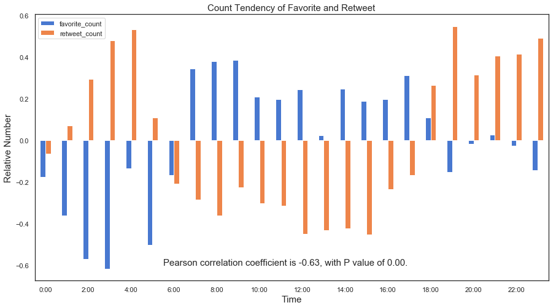

```python
# get the relate number of favorites and retweets
df_group = df_complete[["hour", "favorite_count", "retweet_count"]].groupby(["hour"]).mean()
df_group = ((df_group - df_group.mean()) / (df_group.max() - df_group.min()))

fig, ax = plt.subplots(figsize=(15, 8))
df_group.plot(kind="bar", ax=ax)
ax.set_xticks(np.arange(0, 24, 2))
ax.set_xticklabels([str(i) + ":00" for i in range(0, 26, 2)], rotation=0)
ax.set_xlabel('Time', fontsize=15)
ax.set_ylabel('Relative Number', fontsize=15)
ax.set_title("Count Tendency of Favorite and Retweet", fontsize=15) # add pearson r to the graph
ax.text(x=5.5,y=-0.6,s="Pearson correlation coefficient is %0.2f, with P value of %0.2f."%pearsonr(df_group.favorite_count,
                                                                                  df_group.retweet_count), fontsize=15);
```

> It is fun to see that the average number of favorite and that of retweet goes significantly different towards different trends in the Brexit issue. It might be because the retweets are usually fighting against their previous tweets, and the fighting often happens at night, when they have time to argue.

### 3.3 What are in the Tweets ?

Third, the essay tends to figure out the content of each tweet.

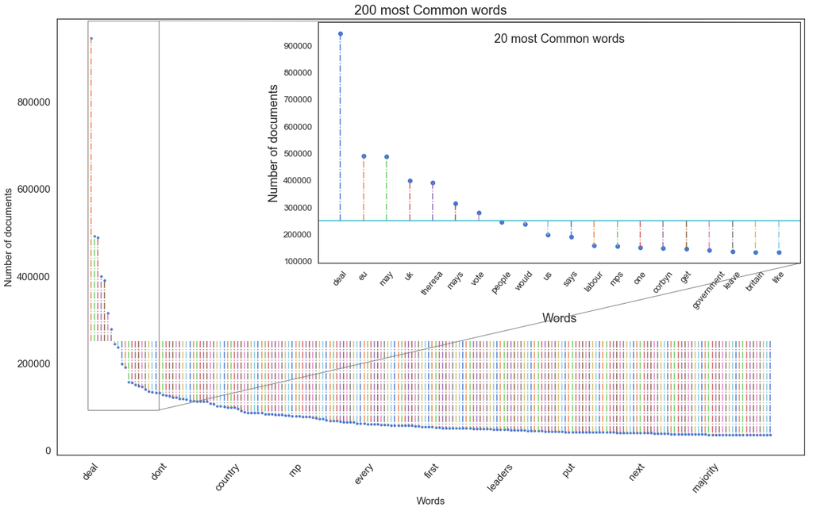

```python
sub_word_count = word_count[1:201]

fig, ax = plt.subplots(figsize=(20, 12))
###### main plot ######
# set '-.' to line , '.' to mark
ax.stem(range(200), sub_word_count, '-.', ".", bottom=250000, basefmt=" ")
# show ticks every 20 labels
ax.set_xticks(np.arange(0, 200, 20))
ax.set_xticklabels(sub_word_count.keys()[::20], rotation=50)
ax.tick_params(labelsize=15)
ax.set_xlabel("Words", fontsize=15)
ax.set_ylabel("Number of documents", fontsize=15)

###### show inset ######
first_word_count = word_count[1:21]

# loc=1 to the right upper corner
axins = inset_axes(ax, 10, 5, loc=1) # insert into previous plot
markerline, stemlines, baseline = axins.stem(range(20), first_word_count, '-.', bottom=250000)
axins.set_xticks(np.arange(0, 20)) # show all labels
axins.set_xticklabels(first_word_count.keys(), rotation=50, fontsize=18)
axins.tick_params(labelsize=13)
axins.set_title("20 most Common words", y=0.9, fontsize=18)
axins.set_xlabel("Words", fontsize=18)
axins.set_ylabel("Number of documents", fontsize=18)

# focus the baseline
plt.setp(baseline, 'color', '#2ab7ca', 'linewidth', 1.5)
baseline.set_xdata([0,1])
baseline.set_transform(plt.gca().get_yaxis_transform())

# draw the mark inset
mark_inset(ax, axins, loc1=1, loc2=4, fc="none", ec="0.5")

ax.set_title("200 most Common words", fontsize=20)
plt.show();
```

> The graph above shows word frequency, in which we can see "deal", "eu", "theresa", and our next target will be looking for the intuitives among these words and people.

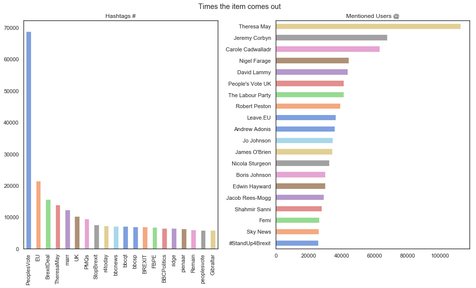

```python
fig, axes = plt.subplots(ncols=2, nrows=1, figsize=(16, 8))
hashtag_count_plot = hashtag_count[(hashtag_count.keys()!="Brexit") & (hashtag_count.keys()!="brexit")]
hashtag_count_plot.head(20).plot(kind='bar', alpha=0.7, ax=axes[0], title="Hashtags #") # remove #brexit which is too many
mention_count.head(20)[::-1].plot(kind='barh', alpha=0.7, ax=axes[1], title="Mentioned Users @") # horizontal bar plot
fig.subplots_adjust(wspace=0.3, top=0.92)
fig.suptitle("Times the item comes out");
```

> Left graph provides the times of each hashtag comes out, whereas right one provides that of each mentioned user. Political issues, politicians and press are most often.

```python
def heat_map(matrix, order, title="", cmap=plt.cm.gray_r):
    """Draw the heatmap.

    Args:
        matrix:
            A np.ndarray. Matrix to plot as a heatmap.
        order:
            A np.ndarray. Order of languages.
        title:
            A string. The title of this graph, default to "".
        cmap:
            A color map. Default to plt.cm.gray_r.
    """

    fig, ax = plt.subplots(figsize=(20, 20))
    cax = ax.matshow(matrix, cmap=cmap)
    fig.colorbar(cax, fraction=0.045)

    # show the language name
    names = np.arange(len(order))
    ax.set_xticks(names)
    ax.set_xticklabels(order, rotation=90)
    ax.set_yticks(names)
    ax.set_yticklabels(order)
    ax.set_title(title, y=-0.05, fontsize=20);

def draw_heat_map(list_need, list_all, title="", cmap=plt.cm.gray_r):
    """Draw the heatmap by the given listed items and the items all documents list.

    Args:
        list_need:
            A list. The items in list will be plot as axis.
        list_all:
            A list. The documents that items happen in.
        title:
            A string. The title of this graph, default to "".
        cmap:
            A color map. Default to plt.cm.gray_r.
    """

    # first construct a matrix to fill
    co_matrix = np.zeros(shape=(len(list_need), len(list_need)))
    for item1 in list_need:
        for item2 in list_need[list_need.index(item1)+1:]: # only iterate the left part
            count_co = 0 # numerator
            count1 = 0 # denominator
            count2 = 0 # denominator
            for mention in list_all: # iterate whole list
                flag1 = item1 in mention
                flag2 = item2 in mention

                if flag1: # calculate how many times item1 happens.
                    count1 += 1
                if flag2: # calculate how many times item2 happens.
                    count2 += 1
                if flag1 and flag2: #calculate how many times both happen.
                    count_co += 1

            if count1 > 0 and count2 >0:
                # co-use/(count of language1^0.5 * count of language2^0.5)
                cs = count_co / (np.sqrt(count1) * np.sqrt(count2))
                co_matrix[list_need.index(item1)][list_need.index(item2)] = cs
                co_matrix[list_need.index(item2)][list_need.index(item1)] = cs

    # get all information in need
    cs_L = np.diag(np.sum(co_matrix,1)) - co_matrix
    cs_D, cs_V = np.linalg.eigh(cs_L)
    cs_V = cs_V[:,np.argsort(cs_D)]

    # permutation in the order of Fiedler vector elements
    fiedler = np.argsort(cs_V[:,1])
    cs_need = [list_need[i] for i in fiedler]
    cs_matrix = co_matrix[fiedler][:,fiedler]

    heat_map(cs_matrix, cs_need, title=title, cmap=cmap)
```

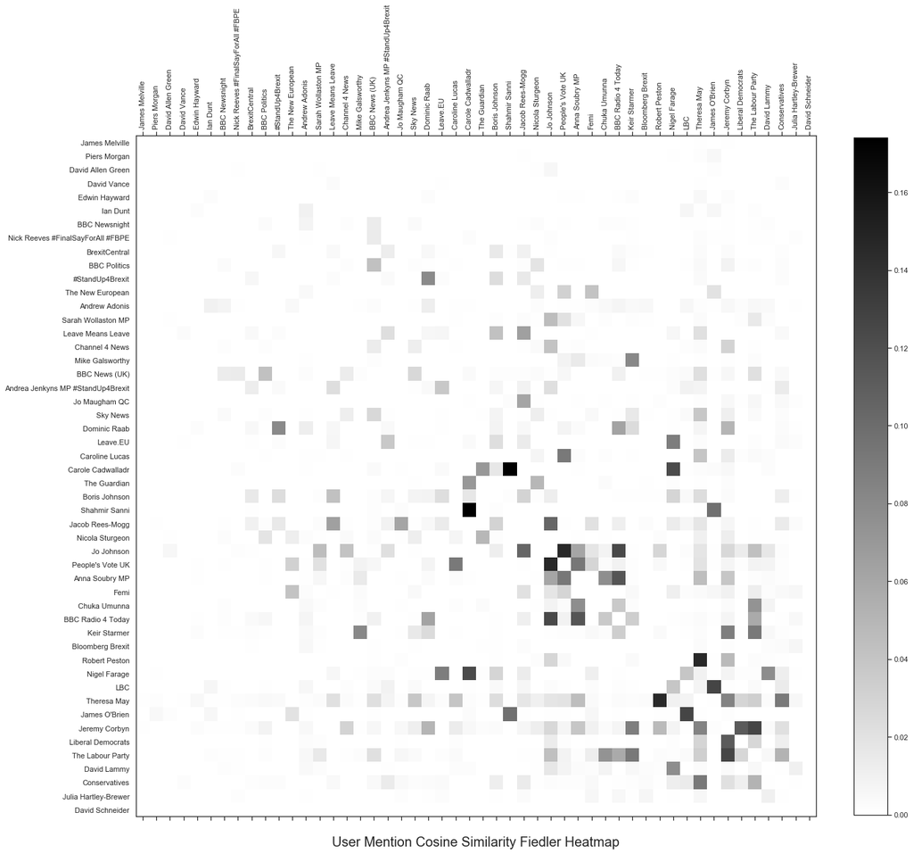

```python
total = 50 # only get the first 100 mentions
user_need = list(mention_count[:total].keys())
draw_heat_map(user_need, user_mentions, title="User Mention Cosine Similarity Fiedler Heatmap")
```

> The graph above shows the correlation of the users mentioned. The darker point means higher correlated between the two users. I hereby highlight the two lower right squares, i.e. Remaining group and Leaving Group:
> - **Remaining: Jo Johnson, People's Vote UK, Anna Soubry, Femi, Chunka Umunna, Keir Starmer.**  
>   Jo, Anna, Chunka and Keir are all members of parliament, while Femi is a cheif Spokesperson of a Brexit Organization. People's Vote is a campaign group calling for public vote on the final Brexit deal between the UK and the EU. The politicians attended its launch event. Most of them stands for a second referendum or at least vote for the final deal.
> - **Leaving: LBC, Theresa May, James O'Brien, Jeremy Corbyn, David Lammy, Julia Hartley-Brewer.**  
>   Except James, a political television presenter who works for LBC, and Julia Hartley-Brewer, a broadcaster, the rest of them votes for remaining, though Jeremy says equivocation all the time.

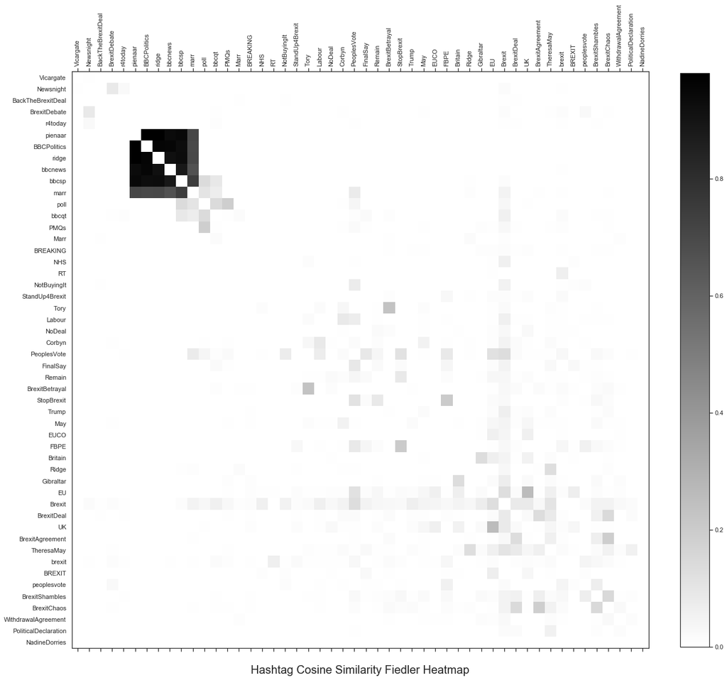

```python
hashtag_need = list(hashtag_count[:total].keys())
draw_heat_map(hashtag_need, hashtags, title="Hashtag Cosine Similarity Fiedler Heatmap")
```

> The graph above clearly gives two squares. The upper left is **press or media related stuffs**, like BBCs, Ridges, Andrew Marr, Prime Minister's Questions. THe lower right shadow though includs **Brexit issues and related politicians**.

## 4. Geography Analysis

### 4.1 Location Sentiment Distribution

The essay now draws the average sentiment from tweets of each country.

```python
formal_name = {} # get the official county name
country_name = {} # get the official country name
for key, value in user_location.items():
    if value != []:
        formal = value[0]["address_components"][0]["long_name"] # county name
        country = value[0]["address_components"][-1]["long_name"] # country name
        # reduce the worthless location name
        if not formal.isdigit() and "#" not in formal and "-" not in formal and formal != "":
            formal_name[key] = formal
        if not country.isdigit() and "#" not in country and "-" not in country and country != "":
            country_name[key] = country

# pair the official name, by input of user, or "" if failed to pair
id_location = users_data.copy()
for user in id_location:
    location = user["location"].lower() # ignore case
    if location in formal_name:
        user["location"] = formal_name[location]
    else:
        user["location"] = ""

    if location in country_name:
        user["country"] = country_name[location]
    else:
        user["country"] = ""

id_location = pd.DataFrame(id_location)
# join the two dataframe by userid
cross_table = id_time.set_index("userid").join(id_location.set_index("id"))
cross_table = cross_table[cross_table["location"]!=""] # forget the unknown ones
# get the mean of sensitive for each location/country
location_sentiment = cross_table[["sentiment", "location"]].groupby("location").mean()
country_sentiment = cross_table[["sentiment", "country"]].groupby("country").mean()
location_X = cross_table[["location", "sentiment", "time",
                          "favorite_count", "retweet_count"]].groupby("location")
location_X = location_X.mean().join(pd.DataFrame(location_X.size().rename("count")))
```

```python
def draw_map(sentiment, uk=True):
    """Draw the sentiment distribution for map

    Args:
        sentiment:
            A dataframe. The sentiment for each location.

    """

    if uk:
        fig, ax = plt.subplots(figsize=(16,12))
        m = Basemap(
            projection='stere',
            llcrnrlon=-11, # left lower point lon
            llcrnrlat=49, # left lower point lat
            urcrnrlon=5,# right upper point lon
            urcrnrlat=61, # right upper point lat
            lon_0=0, # center point lon
            lat_0=51   # center point lat
        )
        m.shadedrelief() # set background
        m.readshapefile("britainmap/gadm36_GBR_2", 'areas')
        attr = "NAME_2" # further join index
        cmap = plt.get_cmap('seismic') # picture params
        pad = 0.05
        shrink = 1
        orient = "vertical"
        ax.set_title("UK sentiments towards Brexit",  fontsize=20)
    else:
        fig, ax = plt.subplots(figsize=(18,20))
        m = Basemap(lon_0=0, projection='robin')
        m.drawmapboundary(color='w') # set background
        m.readshapefile("worldmap/ne_10m_admin_0_countries_lakes", 'areas')
        attr = "NAME" # further join index
        cmap = plt.get_cmap('Blues') # picture params
        ax.axhspan(0, 1000 * 1800, facecolor='w', edgecolor='w', zorder=2)
        pad = 0.0005
        shrink = 0.5
        orient = "horizontal"
        ax.set_title("World sentiments towards Brexit",  y=-0.003, fontsize=20)

    df_poly = pd.DataFrame({
            'shapes': [Polygon(np.array(shape), True) for shape in m.areas],
            'area': [area[attr] for area in m.areas_info]
        })
    df_poly = df_poly.set_index("area").join(sentiment) # join the polygon and input sentiment-location
    # draw the colors to map by location polygon and the color degree by its sentiment
    pc = PatchCollection(df_poly.shapes, zorder=2)
    norm = Normalize()
    pc.set_facecolor(cmap(norm(df_poly['sentiment'].fillna(0).values)))
    ax.add_collection(pc)
    # draw the color bar to new mapper
    mapper = matplotlib.cm.ScalarMappable(norm=norm, cmap=cmap)
    mapper.set_array(df_poly['sentiment'])
    fig.colorbar(mapper, fraction=0.045, orientation=orient, shrink=shrink, pad=pad)
```

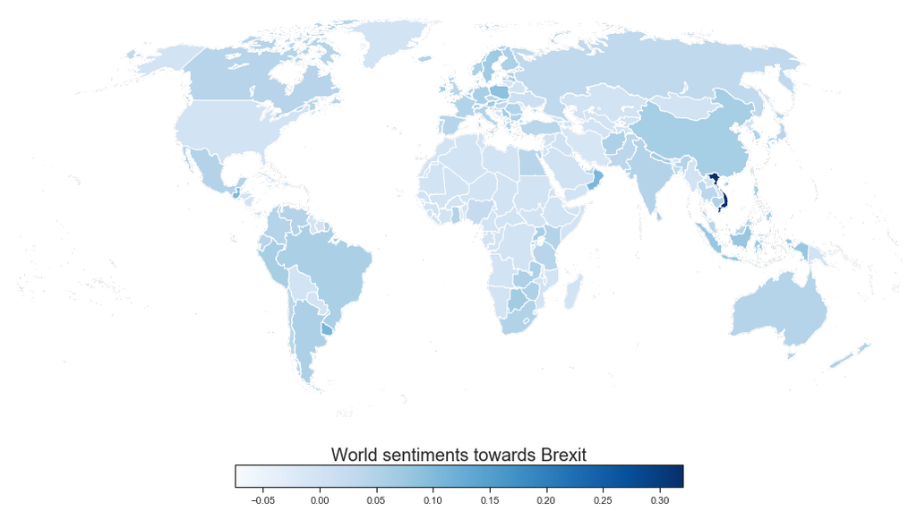

```python
draw_map(country_sentiment, uk=False)
```

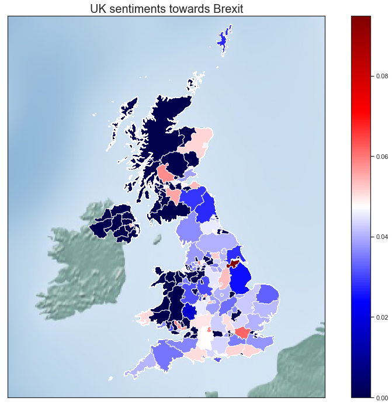

```python
draw_map(location_sentiment)
```

### 4.2 Brexit Prediction Model

The essay takes all the location and sentiment data to make prediction model of Brexit. I divide the UK into electoral districts, and take the referendum data (*Brexitvote.csv*) of each district as ground truth (https://data.london.gov.uk/dataset/eu-referendum-results). The steps are as below.

```
1. Aggregate the location, sentiment, retweets, favorites, time data into one dataframe
2. Group by the location (each electoral district) and take means of all rest
3. Calculate cosine similarity matrix with similarity of each row by each row
4. Use Spectral Co-Clustering to divide districts into two parts, one for Leave and one for Remain
```

```python
brexitvote = pd.read_csv(datafile+"Brexitvote.csv", usecols=["Area", "Remain", "Leave"])
brexitvote["brexit"] = brexitvote["Leave"] > brexitvote["Remain"] # get the brexit flag for each district
uk_X = location_X[location_X.index.isin(brexitvote.Area)] # only use the electoral district
brexit_counties = list(brexitvote.loc[brexitvote["brexit"] & (brexitvote["Area"].isin(uk_X.index)), "Area"])
```

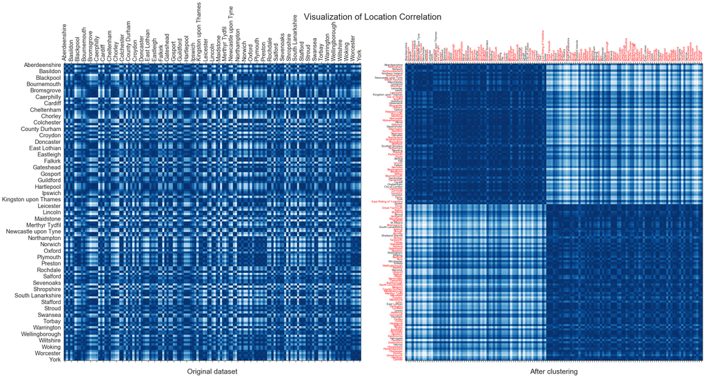

```python
fig, axes = plt.subplots(ncols=2, nrows=1, figsize=(40, 20))

# calculate the cosine similarity matrix and cluster it
X_matrix = cosine_similarity(uk_X)
model = SpectralCoclustering(n_clusters=2, random_state=0)
model.fit(X_matrix)
X_fit = X_matrix[np.argsort(model.row_labels_)]
X_fit = X_fit[:, np.argsort(model.column_labels_)]

# sometimes control the number of labels
for i in range(len(axes)):
    if i == 0:
        X_temp = X_matrix.copy()
        title = "Original dataset"
        tickslabel = uk_X.index
        skip = 3
        fontsize=20
    else:
        X_temp = X_fit.copy()
        title = "After clustering"
        tickslabel = tickslabel[np.argsort(model.row_labels_)]
        skip = 1
        fontsize=10

    ticks = np.arange(0, len(X_matrix), skip)
    axes[i].matshow(X_temp, cmap=plt.cm.Blues) # draw the matrix
    axes[i].set_title(title, y=-0.05, fontsize=25)
    axes[i].set_xticks(ticks)
    axes[i].set_yticks(ticks)
    axes[i].set_xticklabels(tickslabel[::skip], fontsize=fontsize, rotation=90)
    axes[i].set_yticklabels(tickslabel[::skip], fontsize=fontsize)

    # if the location voted "Leave", make it red
    for tick in plt.gca().get_xticklabels():
        if tick.get_text() in brexit_counties:
            tick.set_color("red")

    for tick in plt.gca().get_yticklabels():
        if tick.get_text() in brexit_counties:
            tick.set_color("red")

fig.subplots_adjust(wspace=0.15, top=0.87)
fig.suptitle("Visualization of Location Correlation", fontsize=30);
```

> Left graph shows most districts name for viewing clearly, while right graph shows all the names, because it only cares the red density, which means the ones voting Leave. On the other hand, it is less intuitive seeing all this names into two parts.

> The both graphs show the districts can be significantly divided into two parts, which implies the possibilities they can be distinguished after concerning all these variables.  
> For red density, the lower part is obviously higher than upper part. The essay utilizes this method as a classifier.

```
Precision: 0.8082
Recall:    0.6020
Accuracy:  0.6187
F1:        0.6901
```

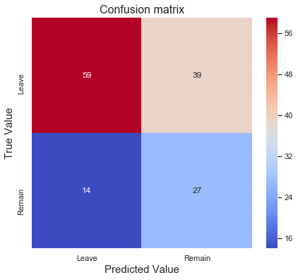

```python
# get real value and predicted value and makes confusion matrix
real_value = ["Leave" if i in brexit_counties else "Remain" for i in tickslabel]
pred_value = ["Leave" if i>=sum(model.biclusters_[0][0]) else "Remain" for i in range(len(real_value))]
cm = confusion_matrix(real_value, pred_value)

fig, ax = plt.subplots(figsize=(7,6))
ax.set_title('Confusion matrix', fontsize=16)
sns.heatmap(cm, annot=True, cmap="coolwarm")
ax.set_xticklabels(["Leave", "Remain"])
ax.set_yticklabels(["Leave", "Remain"])
ax.set_xlabel('Predicted Value', fontsize=15)
ax.set_ylabel('True Value', fontsize=15)

# calculate precision, recall, accuracy and F1
precision = cm[0][0] / (cm[0][0] + cm[1][0])
recall = cm[0][0] / (cm[0][0] + cm[0][1])
accuracy = (cm[0][0] + cm[1][1]) / sum(sum(cm))
f1 = 2 * precision * recall / (precision + recall)

print("Precision: %0.4f"%precision)
print("Recall:    %0.4f"%recall)
print("Accuracy:  %0.4f"%accuracy)
print("F1:        %0.4f"%f1)
```

> Compared with the ground truth from EU referendum, this method gives precision as high as around 0.8, with others not too bad.

> In this sense, the essay introduces this method for further political preidiction. Politicians may acquire these data consistently and once related issues happenning, check which districts need more caring, and target them.

## 5. Conclusion

The essay holds **4,638,226** documents, with nested json format, acquired by my automatical scrapper by Twitter API, after deduplicating over one million. They have now been stored in my personal elasticsearch database, but showed as an example in AWS elasticsearch. With all these data, my main target is to find out whether Twitter can show different but valuable knowledge from normal press.

To achive this, the essay implements sentiment analysis of each text and recovers the location information by re-searching via GoogleMap API. For further study, the essay converts the whole data to five handy files.

The essay firstly presents the tweets information in elegant graphs and picks out the interesting points that favorites count and retweets count behave significantly to the opposite within one full day.

By fiedler heatmap, Leave/Remain group can be found, and the press are highlighted to its own part.

At last, the essay introduces a clustering model, which gives high precision predicting which district will vote for Brexit. Government for gathering the public may take this method to plan initially who need more help.

It is evident to see there are many secrets hidden in tweets. With data analyzing, we dig out the interesting relationship, and provide a nice model.

## 6. Reference

Becker, Sascha O , T. Fetzer , and D. Novy . "Erratum to: Who voted for Brexit? A comprehensive district-level analysis." Economic Policy 32.92(2017).

Bollen, Johan , H. Mao , and X. Zeng . "Twitter mood predicts the stock market." Journal of Computational Science 2.1(2011):1-8.

Friasmartinez, Vanessa , and E. Friasmartinez . Spectral clustering for sensing urban land use using Twitter activity. Pergamon Press, Inc. 2014.

Khatua, Apalak , and A. Khatua . "Leave or Remain? Deciphering Brexit Deliberations on Twitter." IEEE International Conference on Data Mining Workshops IEEE, 2017.

Kolchyna, Olga , et al. "Twitter Sentiment Analysis." Computer Science (2015).

Manuela Hürlimann, et al. "A Twitter Sentiment Gold Standard for the Brexit Referendum." International Conference on Semantic Systems ACM, 2016.

Quercia, Daniele , H. Askham , and J. Crowcroft . "TweetLDA: Supervised Topic Classification and Link Prediction in Twitter." Acm Web Science Conference ACM, 2012.

Zhao, Wayne Xin , et al. "Comparing Twitter and Traditional Media Using Topic Models." Advances in Information Retrieval - 33rd European Conference on IR Research, ECIR 2011, Dublin, Ireland, April 18-21, 2011. Proceedings Springer-Verlag, 2011.